# MS_Lab3

```python
import nltk

from nltk.stem import PorterStemmer
from nltk.stem import LancasterStemmer
from nltk.stem import WordNetLemmatizer
from nltk.corpus import stopwords


from nltk.tokenize import word_tokenize, wordpunct_tokenize

nltk.download('punkt')
nltk.download('wordnet')
nltk.download('stopwords')
```

```
True
```

When working with a text you have to take into account families of words e.g. dog, dogs, doggy. The most popular techniques helping to deal with this issue are lemmatization and stemming. Both are special cases of normalization. They identify a canonical representative for a set of related word forms.

The goal of both stemming and lemmatization is to reduce inflectional forms and sometimes derivationally related forms of a word to a common base form. However, the two words differ in their flavor. Stemming usually refers to a crude heuristic process that chops off the ends of words in the hope of achieving this goal correctly most of the time, and often includes the removal of derivational affixes. Lemmatization usually refers to doing things properly with the use of a vocabulary and morphological analysis of words, normally aiming to remove inflectional endings only and to return the base or dictionary form of a word, which is known as the lemma.

```python
porter = PorterStemmer()
lancaster = LancasterStemmer()
wordnet = WordNetLemmatizer()
```

```python
print("{:15}{:15}{:15}{:15}".format("Word","Porter","Lancaster","WordNet"))
for word in ["was", "cats", "played", "mechanical", "friend", "friendship"]:
    print("{:15}{:15}{:15}{}".format(word, porter.stem(word), lancaster.stem(word), wordnet.lemmatize(word, pos="v")))
```

```
Word           Porter         Lancaster      WordNet
was            wa             was            be
cats           cat            cat            cat
played         play           play           play
mechanical     mechan         mech           mechanical
friend         friend         friend         friend
friendship     friendship     friend         friendship
```

```python
text = """Poznań University of Technology, PUT (Polish name: Politechnika Poznańska) is a university in Poznań,
Poland. Poznań University of Technology is known as one of the best technical universities in Poland. URAP
ranked PUT as in top 6% of world universities and Webometrics ranked it at no. 842 in the world by Google
citations for the year 2015. In 1995 it became the first Polish university to become a member of the Conference
of European Schools for Advanced Engineering Education and Research (CESAER), an organization comprising the best
technical universities in Europe. The university is also a member of the Socrates-Erasmus programme for exchange
students from all over Europe, promoting advanced engineering and a European dimension. The university is home to
many organizations and student circles, and the radio station Afera 98.6 MHz. The university has over
21,000 students and over 1100 academic staffs.""".replace('\n',' ')
```

```python
porter.stem(text)
```

```
'poznań university of technology, put (polish name: politechnika poznańska) is a university in poznań,  poland. poznań university of technology is known as one of the best technical universities in poland. urap  ranked put as in top 6% of world universities and webometrics ranked it at no. 842 in th…
```

As a first step, we have to transform a string into a list of words. It's not as trivial as you might think. Thankfully there are libraries with such functions already implemented.

```python
word_tokenize(text), len(word_tokenize(text))
```

```
(['Poznań',
  'University',
  'of',
  'Technology',
  ',',
  'PUT',
  '(',
  'Polish',
  'name',
  ':',
  'Politechnika',
  'Poznańska',
  ')',
  'is',
  'a',
  'university',
  'in',
  'Poznań',
  ',',
  'Poland',
  '.',
  'Poznań',
  'University',
  'of',
  'Technology',
  'is',
  'known',
  'as',
  'one',
  'of',
  'the',
  'best',
  'technical',
  'universities',
  'in',
  'Poland',
  '.',
  'URAP',
  'ranked',
  'PUT',
```

[output cut: 108 more lines]

```
  'MHz',
  '.',
  'The',
  'university',
  'has',
  'over',
  '21,000',
  'students',
  'and',
  'over',
  '1100',
  'academic',
  'staffs',
  '.'],
 162)
```

```python
wordpunct_tokenize(text), len(wordpunct_tokenize(text))
```

```
(['Poznań',
  'University',
  'of',
  'Technology',
  ',',
  'PUT',
  '(',
  'Polish',
  'name',
  ':',
  'Politechnika',
  'Poznańska',
  ')',
  'is',
  'a',
  'university',
  'in',
  'Poznań',
  ',',
  'Poland',
  '.',
  'Poznań',
  'University',
  'of',
  'Technology',
  'is',
  'known',
  'as',
  'one',
  'of',
  'the',
  'best',
  'technical',
  'universities',
  'in',
  'Poland',
  '.',
  'URAP',
  'ranked',
  'PUT',
```

[output cut: 113 more lines]

```
  'The',
  'university',
  'has',
  'over',
  '21',
  ',',
  '000',
  'students',
  'and',
  'over',
  '1100',
  'academic',
  'staffs',
  '.'],
 167)
```

```python
for x in word_tokenize(text):
    print("{:20} - {:20}".format(x, porter.stem(x)))
```

```
Poznań               - poznań
University           - univers
of                   - of
Technology           - technolog
,                    - ,
PUT                  - put
(                    - (
Polish               - polish
name                 - name
:                    - :
Politechnika         - politechnika
Poznańska            - poznańska
)                    - )
is                   - is
a                    - a
university           - univers
in                   - in
Poznań               - poznań
,                    - ,
Poland               - poland
.                    - .
Poznań               - poznań
University           - univers
of                   - of
Technology           - technolog
is                   - is
known                - known
as                   - as
one                  - one
of                   - of
the                  - the
best                 - best
technical            - technic
universities         - univers
in                   - in
Poland               - poland
.                    - .
URAP                 - urap
ranked               - rank
PUT                  - put
```

[output cut: 107 more lines]

```
98.6                 - 98.6
MHz                  - mhz
.                    - .
The                  - the
university           - univers
has                  - ha
over                 - over
21,000               - 21,000
students             - student
and                  - and
over                 - over
1100                 - 1100
academic             - academ
staffs               - staff
.                    - .
```

```python
print(stopwords.words('english'))
```

```
['i', 'me', 'my', 'myself', 'we', 'our', 'ours', 'ourselves', 'you', "you're", "you've", "you'll", "you'd", 'your', 'yours', 'yourself', 'yourselves', 'he', 'him', 'his', 'himself', 'she', "she's", 'her', 'hers', 'herself', 'it', "it's", 'its', 'itself', 'they', 'them', 'their', 'theirs', 'themselve…
```

## Task

Write function which takes string as input and returns list of stems for reasonable words. Filter out stop words and non-words.

```python
def custom_stemmer(string):
    stemmer = PorterStemmer()
    stopWords = set(stopwords.words('english'))

    words = word_tokenize(string)
    filtered_words = [word for word in words if word.lower() not in stopWords and word.isalpha()]

    stems = [stemmer.stem(word) for word in filtered_words]

    return stems
```

```python
print(custom_stemmer(text))
```

```
['poznań', 'univers', 'technolog', 'put', 'polish', 'name', 'politechnika', 'poznańska', 'univers', 'poznań', 'poland', 'poznań', 'univers', 'technolog', 'known', 'one', 'best', 'technic', 'univers', 'poland', 'urap', 'rank', 'put', 'top', 'world', 'univers', 'webometr', 'rank', 'world', 'googl', 'c…
```

```python
dogsText = 'A lot of dogs love the waters of lakes.'
print(custom_stemmer(dogsText))
```

```
['lot', 'dog', 'love', 'water', 'lake']
```

## Task

Convert a date of yyyy-mm-dd format to dd.mm.yyyy format using regular expresions

```python
import re

s = ["1985-12-4",
    "asd 12-132-133",
    "Afs!@#-2055-12-12",
    "02-03-2020",
    "Is it a date 2012-11-01?"]
```

The following output is expected:

4.12.1985  
asd 12-132-133  
Afs!@#-12.12.2055  
02-03-2020  
Is it a date 01.11.2012?

Use re.sub function

```python
for x in s:
    print(re.sub(r'(\d+)-(\d+).*', r'first number: \g<1>; second number: \g<2>', x))
```

```
first number: 1985; second number: 12
asd first number: 12; second number: 132
Afs!@#-first number: 2055; second number: 12
first number: 02; second number: 03
Is it a date first number: 2012; second number: 11
```

```python
pattern = r'(\d{4})-(\d{1,2})-(\d{1,2})'
#\d{4})year-4 digits
#\d{1,2} month - 1 or 2 digits
#\d{1,2} day

formatted_s = [re.sub(pattern, r'\3.\2.\1', x) for x in s]
#r'\3.\2.\1' -> reformats the date so the day is first, then month, then year


for date in formatted_s:
    print(date)
```

```
4.12.1985
asd 12-132-133
Afs!@#-12.12.2055
02-03-2020
Is it a date 01.11.2012?
```

# OCR

```python
import pytesseract
from PIL import Image
import numpy as np
import cv2
import requests
from io import BytesIO
```

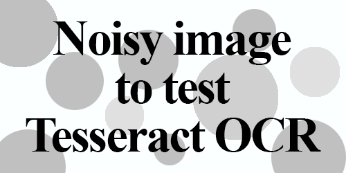

```python
url = "https://i.ibb.co/8d564bB/example-01.png"

response = requests.get(url)
img = Image.open(BytesIO(response.content))

img
```

```python
pytesseract.pytesseract.tesseract_cmd = r'C:\Program Files\Tesseract-OCR\tesseract.exe'
```

```python
print(pytesseract.image_to_string(img))
```

```
Noisyimage
to test
Tesseract OCR
```

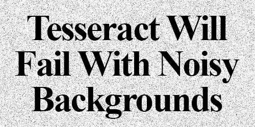

```python
url = "https://i.ibb.co/n63mZfb/example-02.png"
response = requests.get(url)
img = Image.open(BytesIO(response.content))
img
```

```python
print(pytesseract.image_to_string(img))
```

```
_ Tesseract Will
Fail With Noisy
_ Backgrounds —
```

## Task

Read perfectly text from example_02

```python
imperfectText = pytesseract.image_to_string(img)
cleanedText = re.sub(r'[^a-zA-Z\s]', '', imperfectText)
print(cleanedText)
```

```
 Tesseract Will
Fail With Noisy
 Backgrounds
```

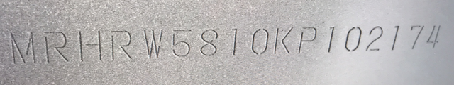

```python
response = requests.get("https://i.ibb.co/1ffsFkx/vin.png")
img = Image.open(BytesIO(response.content))
img
```

```python
print(pytesseract.image_to_string(img))
```

[output not shown]

## Task 5

Read nearly perfectly text from vin.png, 1 error allowed (missing char, additional char, wrong char), 0/O is not an error